# Part II - February 2019 FordGoBike Trip Data

## by Ogochukwu Agina

## Investigation Overview

From 183,412 rides made in February 2019, 89.2% was made by Subscribers while 10.8% was made by Customers. Notwithstanding, the average duration of trips by Customers was twice more than that of Subscribers.

Most rides were made by Subscribers on weekdays between 7 – 9am and 4 – 6pm, with peak usage times at 8am and 5pm. During the week, there is no difference in the bike usage pattern of riders less than 20 years and more than 60 years. For other age groups, especially individuals between 26 and 35 years old, there is a significant decrease in their usage of Ford GoBike on weekends.

For the presentation, I would concentrate on showing the age distribution of riders, daily peak usage times, percentage of riders who are either Subscribers or Customers and their average trip duration. Lastly, I would show the general usage pattern of Subscribers and Customers.

## Dataset Overview

The dataset includes information about bike trips covering San Francisco Bay area for the month of February. It has 16 features including duration of trip, user type, gender, rider's birth year, start and end time of trip

## Distribution of riders by Age group

The age distribution of users in the dataset is from 18 to above 60 years old. Age was grouped in fives and this chart shows that most users of the service are aged 26-30 years, followed by users between 31- 35 years old.

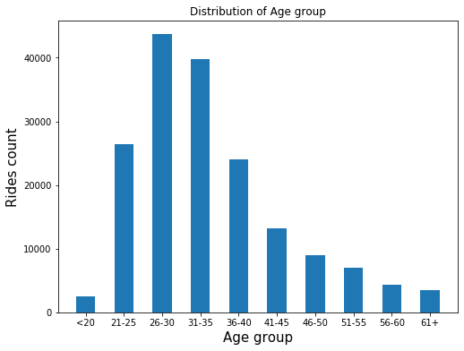

## Usage Peak hours

Most trips take place between 7 – 9am and 4 – 6pm, with peak usage times at 8am in the morning and 5pm later in the day.

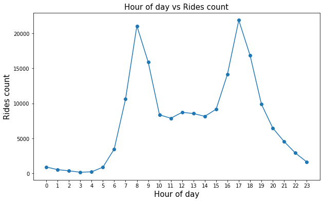

## Number of rides vs Average trip duration for Subscribers and Customers

89.2% of users of Ford GoBike are Subscribers while 10.8% are Customers. However, the average trip duration of Customers is twice more than that of Subscribers. This is clearly depicted by their respective bar charts when placed side to side.

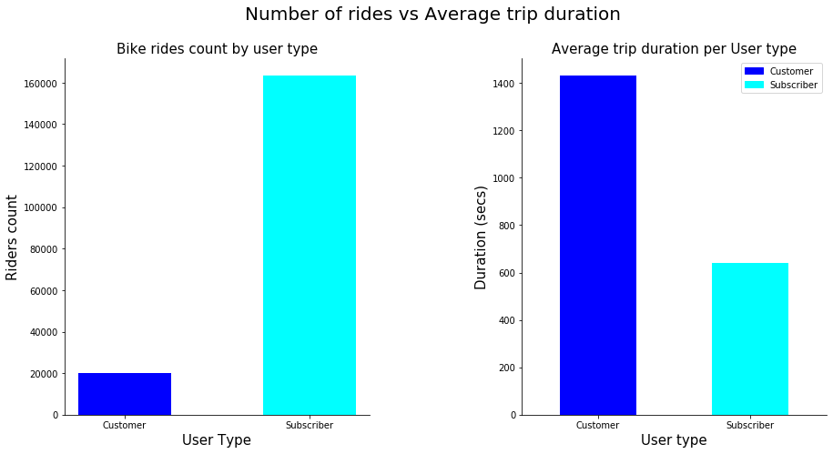

## Usage pattern for Subscribers and Customers

Although the age range of Subscribers and Customers who mostly use Ford GoBike service are the same, their usage patterns during the week varies. While Subscribers made trips mostly on weekdays, Customers regularly made trips every day of the week

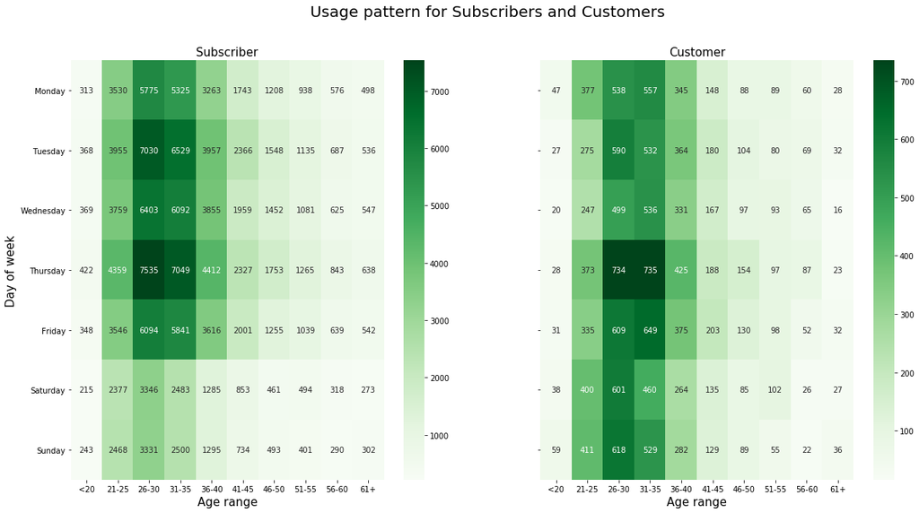